# Exploring probability distributions for cricket

Sayani Gupta

# Introduction

Package `gravitas` is not only restricted to temporal data. An application on cricket follows to illustrate how this package can be generalized in other applications.

The Indian Premier League (IPL) is a professional Twenty20 cricket league in India contested by teams representing different cities in India. In a Twenty20 game the two teams have a single innings each, which is restricted to a maximum of 20 overs. Hence, in this format of cricket, a match will consist of 2 innings, an innings will consist of 20 overs, an over will consist of 6 balls.Hence, a hierarchy table like this can be construed for this game format.

A hierarchy table for T20 cricket

| units | convert_fct |
| --- | --- |
| index | 1 |
| ball | 6 |
| over | 20 |
| inning | 2 |
| match | 1 |

The ball by ball data for IPL season is sourced from [Kaggle](https://www.kaggle.com/josephgpinto/ipl-data-analysis/data). The `cricket` data set in the `gravitas` package summaries the ball-by-ball data cross overs and contains information for a sample of 214 matches spanning 9 seasons (2008 to 2016).

```r
library(gravitas)
library(tibble)
glimpse(cricket)
```

```
#> Observations: 8,560
#> Variables: 10
#> $ season        <dbl> 2008, 2008, 2008, 2008, 2008, 2008, 2008, 2008, 20…
#> $ match_id      <dbl> 2, 2, 2, 2, 2, 2, 2, 2, 2, 2, 2, 2, 2, 2, 2, 2, 2,…
#> $ batting_team  <chr> "Chennai Super Kings", "Chennai Super Kings", "Che…
#> $ bowling_team  <chr> "Kings XI Punjab", "Kings XI Punjab", "Kings XI Pu…
#> $ inning        <dbl> 1, 1, 1, 1, 1, 1, 1, 1, 1, 1, 1, 1, 1, 1, 1, 1, 1,…
#> $ over          <dbl> 1, 2, 3, 4, 5, 6, 7, 8, 9, 10, 11, 12, 13, 14, 15,…
#> $ wicket        <dbl> 0, 0, 1, 0, 0, 0, 1, 1, 0, 0, 0, 0, 1, 0, 0, 1, 0,…
#> $ dot_balls     <dbl> 4, 2, 4, 3, 3, 3, 1, 3, 1, 2, 1, 0, 2, 1, 0, 3, 0,…
#> $ runs_per_over <dbl> 5, 14, 2, 6, 9, 11, 9, 8, 13, 5, 19, 20, 4, 10, 18…
#> $ run_rate      <dbl> 1, 2, 0, 1, 2, 2, 2, 1, 2, 1, 3, 3, 1, 2, 3, 1, 2,…
```

There are many interesting questions that can possibly be answered with such a data set. We will explore a few to understand how the package can help answer some of the questions.

Although there is no conventional time element in cricket, we can still represent the data set `cricket` through a `tsibble`, where each over, which represents an ordering from past to future, can form the `index` of the tsibble.

```r
cricket_tsibble <- cricket %>%
  mutate(data_index = row_number()) %>%
  as_tsibble(index = data_index)

cricket_tsibble
```

```
#> # A tsibble: 8,560 x 11 [1]
#>    season match_id batting_team bowling_team inning  over wicket dot_balls
#>     <dbl>    <dbl> <chr>        <chr>         <dbl> <dbl>  <dbl>     <dbl>
#>  1   2008        2 Chennai Sup… Kings XI Pu…      1     1      0         4
#>  2   2008        2 Chennai Sup… Kings XI Pu…      1     2      0         2
#>  3   2008        2 Chennai Sup… Kings XI Pu…      1     3      1         4
#>  4   2008        2 Chennai Sup… Kings XI Pu…      1     4      0         3
#>  5   2008        2 Chennai Sup… Kings XI Pu…      1     5      0         3
#>  6   2008        2 Chennai Sup… Kings XI Pu…      1     6      0         3
#>  7   2008        2 Chennai Sup… Kings XI Pu…      1     7      1         1
#>  8   2008        2 Chennai Sup… Kings XI Pu…      1     8      1         3
#>  9   2008        2 Chennai Sup… Kings XI Pu…      1     9      0         1
#> 10   2008        2 Chennai Sup… Kings XI Pu…      1    10      0         2
#> # … with 8,550 more rows, and 3 more variables: runs_per_over <dbl>,
#> #   run_rate <dbl>, data_index <int>
```

# How run rates vary depending on if a team bats first or 2nd?

We filtered the data for two top teams in IPL - Mumbai Indians and Chennai Super Kings. Each inning of the match is plotted across facets and overs of the innings are plotted across the x-axis. It can be observed from the letter value plot that there is no clear upward shift in runs in the second innings as compared to the first innings. The variability in runs increase as the teams approach towards the end of the innings, as observed through the longer and more distinct letter values.

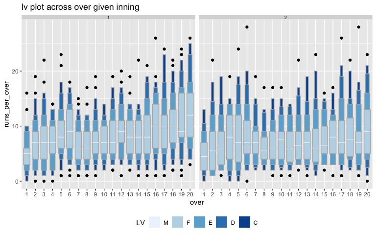

```r
cricket_tsibble %>%
  filter(batting_team %in% c("Mumbai Indians",
                             "Chennai Super Kings"))%>%
  prob_plot("inning", "over",
  hierarchy_model,
  response = "runs_per_over",
  plot_type = "lv")
```

# Do wickets and dot balls affect the runs differently across overs?

A dot ball is a delivery bowled without any runs scored off it. The number of dot balls is reflective of the quality of bowling in the game. The number of wickets per can be thought to be a measure of good fielding. It might be interesting to see how good fielding or bowling affect runs per over differently.

Now, number of wickets/dot balls per over do not appear in the hierarchy table, but they can still be thought of as granularities since they are constructed for each index (over) of the tsibble. The relationship is not periodic because number of wickets that are dismissed or dot balls that are being bowled changes across overs. This is unlike the periodic relationship for units specified in the hierarchy table.

```r
p1 <- cricket_tsibble %>%
  gran_advice("wicket",
            "over",
            hierarchy_model)
```

```r
cricket_tsibble %>%
  gran_advice("dot_balls",
            "over",
            hierarchy_model)
```

```
#> The chosen granularities are clashes.
#>         Consider looking at harmony() to obtain possible harmonies
#>
#> Recommended plots are: quantile
#>
#> Number of observations are homogenous across facets
#>
#> Number of observations are homogenous within facets
#>
#> Cross tabulation of granularities :
#>
#> # A tibble: 20 x 8
#>    over    `0`   `1`   `2`   `3`   `4`   `5`   `6`
#>    <fct> <dbl> <dbl> <dbl> <dbl> <dbl> <dbl> <dbl>
#>  1 1         2    18    74   126   125    68    15
#>  2 2         6    38    80   133   105    57     9
#>  3 3        14    41   113   135    90    31     4
#>  4 4        17    62   114   124    80    25     6
#>  5 5        21    70   104   110    86    34     3
#>  6 6        20    66   111   125    76    24     6
#>  7 7        41   105   123   104    44    11     0
#>  8 8        53   105   129    82    44    15     0
#>  9 9        45   122   125    78    44    12     2
#> 10 10       52   141   109    83    35     7     1
#> 11 11       61   112   125    86    36     7     1
#> 12 12       69   137   117    71    27     7     0
#> 13 13       70   116   114    89    33     5     1
#> 14 14       62   134   114    81    22    14     1
#> 15 15       63   125   133    73    30     4     0
#> 16 16       80   148   121    49    20     9     1
#> 17 17       81   148   107    58    25     9     0
#> 18 18       72   128   145    57    24     2     0
#> 19 19       77   146   108    66    25     6     0
#> 20 20       72   141   117    62    29     6     1
```

Moreover, tt seems like with zero or one wicket, there is still an upward trend in runs across overs of the innings, whereas the same is not true for dot balls more than 0 per over.

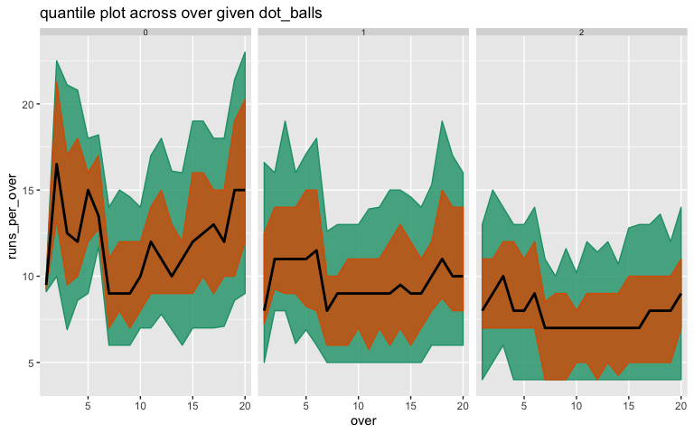

```r
cricket_tsibble %>%
  filter(dot_balls %in% c(0, 1, 2)) %>%
  prob_plot("dot_balls",
            "over",
            hierarchy_model,
            response = "runs_per_over",
            plot_type = "quantile",
            quantile_prob = c(0.1, 0.25, 0.5, 0.75, 0.9))
```

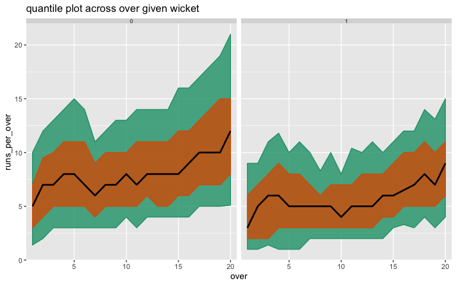

```r
cricket_tsibble %>%
  filter(wicket %in% c(0, 1)) %>%
  prob_plot("wicket",
            "over",
            hierarchy_model,
            response = "runs_per_over",
            plot_type = "quantile",
            quantile_prob = c(0.1, 0.25, 0.5, 0.75, 0.9))
```